# Explainable AI voor studieresultaten

## Inleiding

Dit notebook is het resultaat van 16 weken onderzoek, uitgevoerd in opdracht van de Hogeschool van Arnhem en Nijmegen. Met behulp van Machine Learning zijn verbanden tussen studentgedrag en studieresultaat vastgesteld.

De factoren die (negatief) bijdragen aan een goed studieresultaat worden vergeleken met de resultaten uit eerder uitgevoerde onderzoeken.

**Let op:** in verband met de gevoeligheid van de data betreft deze pagina slechts een export van het Notebook. Daarom is alle data die hier staat statisch. In het ingeleverde ZIP-bestand vindt u het echte notebook.

Het volledige onderzoeksverslag leest u [hier](https://nots-xai.github.io/onderzoeksverslag/).

[video not shown]

**Import dependencies**

```python
import xgboost
import numpy as np
import pandas as pd
import shap
import matplotlib.pyplot as plt
import seaborn as sns
shap.initjs()
from IPython.display import clear_output

%matplotlib inline
```

## Data

De dataset is opgesteld in samenwerking met Arnoud van Bers, propedeusecoördinator van AIM op de HAN. De features in de dataset zijn gekozen op basis van literatuuronderzoek en een enquête onder docenten op HAN.

### Initiële dataset

Het onderstaande *sample* toont de dataset zoals aangeleverd door de HAN.

```python
initial_df = pd.read_excel('./studieresultaten-original.xls')
initial_df.sample(5)
```

|  | prs_PersoonsID | AfstandSchool | pcp_Regio | isc_VanDatum | isc_OpleidingsCode | LeeftijdMaandenEersteInschr | NrStdInEersteKlas | Geslacht | AantalOplVOORICAIngeschreven | PCertificaat_Opl | PropCertificaatDatum | HeeftP | VoorOpleidingsNiveau | HeeftWisInVooropleiding | Aanwezigheid1ejaar | EersteToetsCijfer | GemToetsCijferEerstePeriode | HeeftBijzOmstandigheden |
| --- | --- | --- | --- | --- | --- | --- | --- | --- | --- | --- | --- | --- | --- | --- | --- | --- | --- | --- |
| 7048 | 512804 | 27.0 | Nijmegen | 2018-09-01 | CMD | 298.0 | 32.0 | Man | 1 | NaN | NaT | NaN | MBO | ? | 43.4 | 67.0 | 55.0 | 0 |
| 511 | 171384 | 29.0 | Den Bosch Eindhoven | 2007-02-01 | CMD | 256.0 | 31.0 | Man | 3 | CMD | 2006-06-29 | 1.0 | HAVO | ? | NaN | 40.0 | 65.0 | ? |
| 5557 | 502907 | 21.0 | Nijmegen | 2016-09-01 | CMD | 225.0 | 27.0 | Man | 1 | CMD | 2017-06-30 | 1.0 | HAVO | 1 | 75.5 | 80.0 | 68.0 | 0 |
| 6998 | 512232 | 5.0 | Arnhem | 2018-09-01 | ICT | 219.0 | 30.0 | Man | 1 | NaN | NaT | NaN | HAVO | 1 | 62.3 | 74.0 | 50.0 | 0 |
| 3596 | 468929 | 7.0 | Arnhem | 2013-09-01 | INN | 218.0 | 24.0 | Man | 1 | NaN | NaT | NaN | HAVO | 0 | NaN | 72.0 | 38.0 | ? |

### Irrelevante kolommen

De dataset bevat een aantal aantal kolommen die niet relevant zijn voor dit onderzoek. Onderstaande tabel bevat de kolommen die verwijderd zullen worden.

[output not shown]

### Uiteindelijke dataset

Om de originele dataset geschikt te maken voor Machine Learning, is deze getransformeerd met een [pythonscript](https://github.com/NOTS-XAI/studieresultaten). Alle *categorical columns* zijn geconverteerd naar integers:

```
'VoorOpleidingsNiveau': {
    'NaN': 0,
    'Onbekend': 0,
    'HAVO': 1,
    'HAVO - Oude stijl': 2,
    'HAVO oude stijl': 2,
    'VWO': 3,
    'VWO oude stijl': 4,
    'MBO': 5,
    'Buitenlands': 6,
    'Overige': 7,
    'Anders': 7
},
'Geslacht': {
    'Man': 0,
    'Vrouw': 1
}
```

```python
df = pd.read_csv("https://gist.githubusercontent.com/studieresultaten.csv")
df.describe()
```

|  | AfstandSchool | LeeftijdMaandenEersteInschr | NrStdInEersteKlas | Geslacht | AantalOplVOORICAIngeschreven | HeeftP | VoorOpleidingsNiveau | HeeftWisInVooropleiding | Aanwezigheid1ejaar | EersteToetsCijfer | GemToetsCijferEerstePeriode | HeeftBijzOmstandigheden |
| --- | --- | --- | --- | --- | --- | --- | --- | --- | --- | --- | --- | --- |
| count | 3849.000000 | 3849.000000 | 3849.000000 | 3849.000000 | 3849.000000 | 3849.000000 | 3849.000000 | 3849.000000 | 3849.000000 | 3849.000000 | 3849.000000 | 3849.000000 |
| mean | 22.062614 | 239.637308 | 28.169135 | 0.168615 | 1.241102 | 0.487919 | 2.591842 | 0.281372 | 70.576254 | 68.642505 | 62.548454 | 0.088335 |
| std | 21.986541 | 28.648398 | 3.589040 | 0.374460 | 0.611365 | 0.499919 | 1.926386 | 0.947186 | 23.338332 | 17.486705 | 12.441518 | 0.283818 |
| min | 0.000000 | 191.000000 | 4.000000 | 0.000000 | 1.000000 | 0.000000 | 1.000000 | -1.000000 | 0.000000 | 0.000000 | 0.000000 | 0.000000 |
| 25% | 6.000000 | 218.000000 | 26.000000 | 0.000000 | 1.000000 | 0.000000 | 1.000000 | -1.000000 | 57.800000 | 60.000000 | 56.000000 | 0.000000 |
| 50% | 18.000000 | 235.000000 | 28.000000 | 0.000000 | 1.000000 | 0.000000 | 1.000000 | 1.000000 | 76.800000 | 70.000000 | 64.000000 | 0.000000 |
| 75% | 29.000000 | 254.000000 | 31.000000 | 0.000000 | 1.000000 | 1.000000 | 5.000000 | 1.000000 | 88.500000 | 80.000000 | 71.000000 | 0.000000 |
| max | 177.000000 | 618.000000 | 36.000000 | 1.000000 | 7.000000 | 1.000000 | 7.000000 | 1.000000 | 100.000000 | 100.000000 | 100.000000 | 1.000000 |

### Datanormalizatie

De features moeten eerst genormalizeerd worden, omdat de verschillende features erg verschillen van schaal. Zo is het gemiddelde van `LeeftijdMaandenEersteInschr` 239, terwijl `GemToetsCijferEerstePeriode` gemiddeld 62 is.

```python
normalized_df=(df-df.min())/(df.max()-df.min())
normalized_df.sample(5)
```

|  | AfstandSchool | LeeftijdMaandenEersteInschr | NrStdInEersteKlas | Geslacht | AantalOplVOORICAIngeschreven | HeeftP | VoorOpleidingsNiveau | HeeftWisInVooropleiding | Aanwezigheid1ejaar | EersteToetsCijfer | GemToetsCijferEerstePeriode | HeeftBijzOmstandigheden |
| --- | --- | --- | --- | --- | --- | --- | --- | --- | --- | --- | --- | --- |
| 2082 | 0.000000 | 0.142857 | 0.71875 | 0.0 | 0.000000 | 1.0 | 0.000000 | 1.0 | 0.826 | 0.80 | 0.77 | 0.0 |
| 2239 | 0.033898 | 0.028103 | 0.84375 | 0.0 | 0.000000 | 0.0 | 0.000000 | 1.0 | 0.789 | 0.63 | 0.58 | 0.0 |
| 2 | 0.033898 | 0.393443 | 0.46875 | 0.0 | 0.500000 | 0.0 | 0.333333 | 1.0 | 0.175 | 0.51 | 0.53 | 0.0 |
| 3197 | 0.073446 | 0.196721 | 0.68750 | 0.0 | 0.000000 | 0.0 | 0.666667 | 0.0 | 0.452 | 0.61 | 0.48 | 0.0 |
| 468 | 0.056497 | 0.058548 | 0.65625 | 0.0 | 0.166667 | 0.0 | 0.000000 | 1.0 | 0.411 | 0.70 | 0.56 | 0.0 |

### Man/vrouw verhouding

De dataset bevat alleen gegevens van studenten van ICA/AIM. De man-vrouwverhouding weerspiegelt dat.

```
Aantal mannen:  3200 (83.14%)
Aantal vrouwen:  649 (16.86%)
```

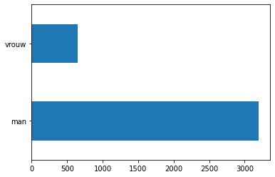

```python
plt.figure()
df["Geslacht"].map({0: "man", 1: "vrouw"}).value_counts().plot(kind="barh")

num_obs = len(df)
num_male = len(df.loc[df['Geslacht'] == 0])
num_female = len(df.loc[df['Geslacht'] == 1])
print("Aantal mannen:  {0} ({1:2.2f}%)".format(num_male, (num_male/num_obs) * 100))
print("Aantal vrouwen:  {0} ({1:2.2f}%)".format(num_female, (num_female/num_obs) * 100))
```

```python
from sklearn.model_selection import train_test_split
y = normalized_df['HeeftP'].astype('int8')
x = normalized_df.loc[:, df.columns != 'HeeftP']
xtrain, xtest, ytrain, ytest=train_test_split(x, y, test_size=0.15, random_state=7)
x.sample(5)
```

|  | AfstandSchool | LeeftijdMaandenEersteInschr | NrStdInEersteKlas | Geslacht | AantalOplVOORICAIngeschreven | VoorOpleidingsNiveau | HeeftWisInVooropleiding | Aanwezigheid1ejaar | EersteToetsCijfer | GemToetsCijferEerstePeriode | HeeftBijzOmstandigheden |
| --- | --- | --- | --- | --- | --- | --- | --- | --- | --- | --- | --- |
| 1346 | 0.079096 | 0.067916 | 0.81250 | 0.0 | 0.000000 | 0.000000 | 1.0 | 0.536 | 0.70 | 0.57 | 0.0 |
| 172 | 0.016949 | 0.145199 | 0.65625 | 0.0 | 0.166667 | 0.666667 | 0.0 | 0.852 | 0.65 | 0.65 | 0.0 |
| 2518 | 0.175141 | 0.079625 | 0.81250 | 0.0 | 0.000000 | 0.000000 | 1.0 | 0.383 | 0.67 | 0.59 | 0.0 |
| 1340 | 0.129944 | 0.142857 | 0.62500 | 0.0 | 0.000000 | 0.666667 | 0.0 | 0.304 | 0.68 | 0.44 | 0.0 |
| 807 | 0.011299 | 0.119438 | 0.65625 | 0.0 | 0.166667 | 0.333333 | 1.0 | 0.813 | 0.89 | 0.79 | 0.0 |

## Initiële model

Om de resultaten uit het deelonderzoek algoritmes ([H2.5](https://docs.google.com/document/d/1BaX9CyMad-uV8utKZYTnn_R70gaXkNW2dV3DKtF2lEk/edit#heading=h.rzr9rxsz2cvx)) zijn veelbelovend (~80% accuracy). Helaas is de gebruikte library (Tensorflow) niet compatibel met SHAP.

Daarom is er voor gekozen om het deelonderzoek te repliceren met een de `XGBClassifier` van XGBoost. Deze classifier maakt gebruik van `gradient boosted trees` en is compatibel met [SHAP](https://github.com/slundberg/shap).

```python
xgbc = xgboost.XGBClassifier(
    use_label_encoder=False,
    max_depth = 3,
    n_estimators = 150,
    objective='binary:logistic'
)
```

```python
train_x = xtrain.values
test_x = xtest.values
eval_set = [(train_x, ytrain), (test_x, ytest)]

xgbc.fit(
    train_x,
    ytrain,
    eval_metric=["error", "logloss"],
    eval_set=eval_set
)
clear_output()
```

**Plot de loss en classificatie errors**

In de twee onderstaande grafieken is het verloop van de loss en het percentage classificatie errors te zien. De loss/error rate van het trainingset blijft dalen, terwijl de loss/error rate van de testset na 1/3e van de trainingstijd weer omhoog gaat. Dit betekent dat er overfitting plaatsvindt. Overfitting betekent dat het model te nauw is verbonden met het trainingsdataset en voor andere data veel minder geschikt is.

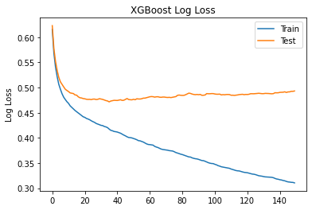

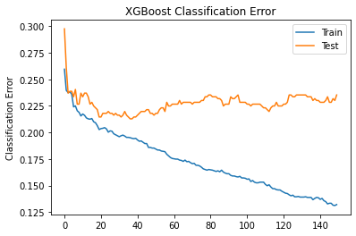

```python
from matplotlib import pyplot
results = xgbc.evals_result()
epochs = len(results['validation_0']['error'])
x_axis = range(0, epochs)
# plot log loss
fig, ax = pyplot.subplots()
ax.plot(x_axis, results['validation_0']['logloss'], label='Train')
ax.plot(x_axis, results['validation_1']['logloss'], label='Test')
ax.legend()
pyplot.ylabel('Log Loss')
pyplot.title('XGBoost Log Loss')
pyplot.show()
# plot classification error
fig, ax = pyplot.subplots()
ax.plot(x_axis, results['validation_0']['error'], label='Train')
ax.plot(x_axis, results['validation_1']['error'], label='Test')
ax.legend()
pyplot.ylabel('Classification Error')
pyplot.title('XGBoost Classification Error')
pyplot.show()
```

### Model met early stopping

Om overfitting tegen te gaan, kan *early stopping* gebruikt worden. Dit betekent dat het model stopt met trainen op het moment dat er geen verlaging in *loss* is in een vooraf gedefinieerd aantal rondes. In de bovenstaande grafieken is te zien dat de *loss* en *error rate* achteruit gaan tussen ronde 40 en 50. Daarom is er gekozen voor een `early_stopping_rounds` parameter van `10`.

```python
xgbc.fit(
    train_x,
    ytrain,
    eval_metric=["error", "logloss"],
    eval_set=eval_set,
    early_stopping_rounds=10, # early stopping
)
clear_output()
```

**Plot de loss en classificatie errors**

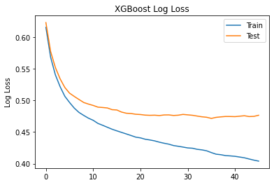

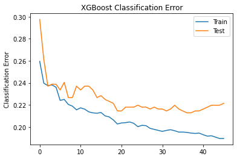

```python
from matplotlib import pyplot
results = xgbc.evals_result()
epochs = len(results['validation_0']['error'])
x_axis = range(0, epochs)
# plot log loss
fig, ax = pyplot.subplots()
ax.plot(x_axis, results['validation_0']['logloss'], label='Train')
ax.plot(x_axis, results['validation_1']['logloss'], label='Test')
ax.legend()
pyplot.ylabel('Log Loss')
pyplot.title('XGBoost Log Loss')
pyplot.show()
# plot classification error
fig, ax = pyplot.subplots()
ax.plot(x_axis, results['validation_0']['error'], label='Train')
ax.plot(x_axis, results['validation_1']['error'], label='Test')
ax.legend()
pyplot.ylabel('Classification Error')
pyplot.title('XGBoost Classification Error')
pyplot.show()
```

### Voorspellingen

De confusion matrix is een simpele tabel die het aantal *true en false positives* en het aantal *true en false negatives* weergeeft. Hieruit kan de *accuracy* van het model afgeleid worden.

**Table formatting**

```python
%%html
<style>
table {float:left}
</style>
```

**Confusion matrix**

```python
from sklearn.metrics import confusion_matrix

ypred = xgbc.predict(test_x)
cm = confusion_matrix(ytest,ypred)
print(cm)
```

```
[[230  66]
 [ 58 224]]
```

|  |  | Predicted label |  |
| --- | --- | --- | --- |
|  |  | 0 | 1 |
| **Actual label** | 0 | 230 True negatives | 66 False positives |
|  | 1 | 58 False negatives | 224 True positives |

**Accuracy**

Met behulp van scikit-learn kan gemakkelijk de accuracy van het model berekend worden. Deze score kan ook handmatig berekend worden met de volgende formule:  
(True Negatives + True Positives) / (Positives + Negatives) * 100

```python
print(( 230 + 224 ) / ( 230 + 66 + 58 + 224 ) * 100)
```

```
78.54671280276817
```

```python
from sklearn.metrics import accuracy_score
y_pred = xgbc.predict(test_x)
predictions = [round(value) for value in y_pred]
# evaluate predictions
accuracy = accuracy_score(ytest, predictions)
print("Accuracy: %.2f%%" % (accuracy * 100.0))
```

```
Accuracy: 78.55%
```

```python
from sklearn.model_selection import cross_val_score, KFold

scores = cross_val_score(xgbc, xtrain, ytrain, cv=5)
clear_output()
print("Mean cross-validation score: %.2f" % scores.mean())
```

```
Mean cross-validation score: 0.76
```

```python
kfold = KFold(n_splits=10, shuffle=True)
kf_cv_scores = cross_val_score(xgbc, xtrain, ytrain, cv=kfold )
clear_output()
print("K-fold CV average score: %.2f" % kf_cv_scores.mean())
```

```
K-fold CV average score: 0.76
```

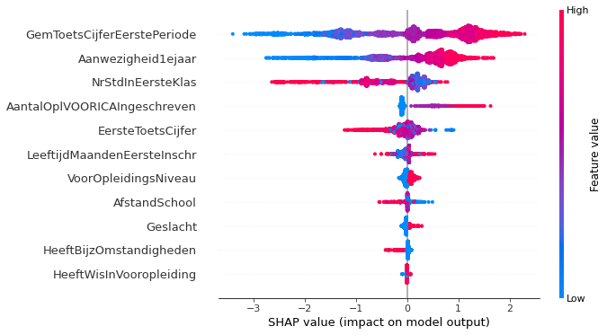

```python
# Summarize the training set to accelerate analysis
train_summary = shap.kmeans(xtrain.values, 40)

explainer = shap.TreeExplainer(xgbc, train_summary.data)

shap_values = explainer.shap_values(xtrain)

shap.summary_plot(shap_values, xtrain)
```

```python
from sklearn.metrics import accuracy_score
y_pred = xgbc.predict(xtest.values)
predictions = [round(value) for value in y_pred]
```

```python
# evaluate predictions
accuracy = accuracy_score(ytest, predictions)
print("Accuracy: %.2f%%" % (accuracy * 100.0))
```

```
Accuracy: 78.55%
```

```python
def displayDependencePlots(shap_values, show=False):
    shap.dependence_plot('NrStdInEersteKlas', shap_values, xtrain, interaction_index='NrStdInEersteKlas', show=False)
    plt.savefig('NrStdInEersteKlas.png')

    shap.dependence_plot('EersteToetsCijfer', shap_values, xtrain, interaction_index='EersteToetsCijfer', show=False)
    plt.savefig('EersteToetsCijfer.png')

    shap.dependence_plot('GemToetsCijferEerstePeriode', shap_values, xtrain, interaction_index='GemToetsCijferEerstePeriode', show=False)
    plt.savefig('GemToetsCijferEerstePeriode.png')

    shap.dependence_plot('Aanwezigheid1ejaar', shap_values, xtrain, interaction_index='Aanwezigheid1ejaar', show=False)
    plt.savefig('Aanwezigheid1ejaar.png')

    shap.dependence_plot('LeeftijdMaandenEersteInschr', shap_values, xtrain, interaction_index='LeeftijdMaandenEersteInschr', show=False)
    plt.savefig('LeeftijdMaandenEersteInschr.png')

    shap.dependence_plot('AantalOplVOORICAIngeschreven', shap_values, xtrain, interaction_index='AantalOplVOORICAIngeschreven', show=False)
    plt.savefig('AantalOplVOORICAIngeschreven.png')

    shap.dependence_plot('VoorOpleidingsNiveau', shap_values, xtrain, interaction_index='VoorOpleidingsNiveau', show=False)
    plt.savefig('VoorOpleidingsNiveau.png')

    shap.dependence_plot('AfstandSchool', shap_values, xtrain, interaction_index='AfstandSchool', show=False)
    plt.savefig('AfstandSchool.png')

    shap.dependence_plot('HeeftWisInVooropleiding', shap_values, xtrain, interaction_index='HeeftWisInVooropleiding', show=False)
    plt.savefig('HeeftWisInVooropleiding.png')

    shap.dependence_plot('HeeftBijzOmstandigheden', shap_values, xtrain, interaction_index='HeeftBijzOmstandigheden', show=False)
    plt.savefig('HeeftBijzOmstandigheden.png')

    shap.dependence_plot('Geslacht', shap_values, xtrain, interaction_index='Geslacht', show=False)
    plt.savefig('Geslacht.png')
```

```python
displayDependencePlots(shap_values)
```

```
Passing parameters norm and vmin/vmax simultaneously is deprecated since 3.3 and will become an error two minor releases later. Please pass vmin/vmax directly to the norm when creating it.
```

## Individuele plots

### Aantal studenten in eerste klas

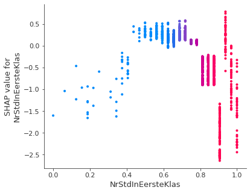

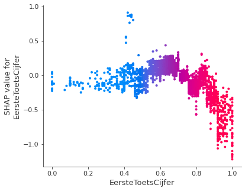

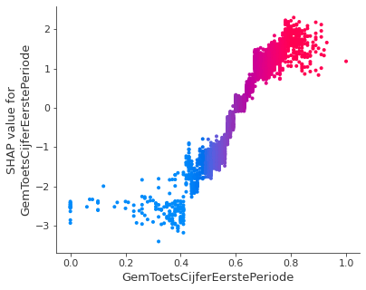

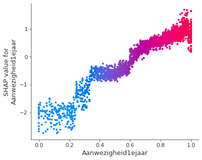

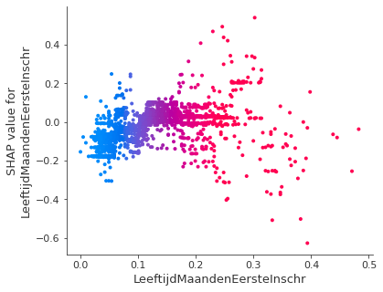

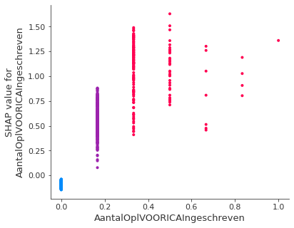

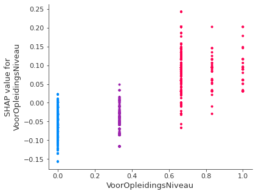

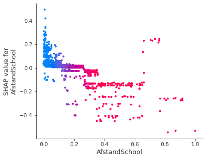

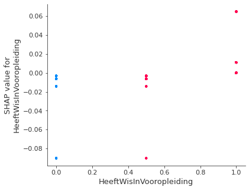

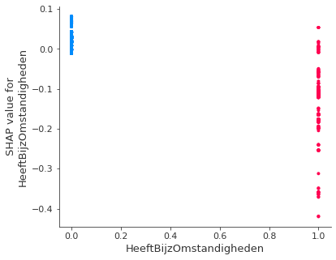

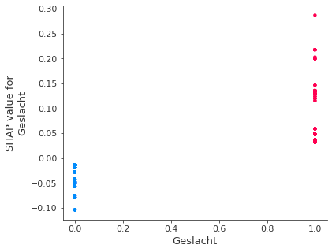

```python
shap.force_plot(explainer.expected_value, shap_values[11,:], xtrain.iloc[11,:])
```

```python
shap.force_plot(explainer.expected_value, shap_values, xtrain)
```

```
shap.plots.force is slow for many thousands of rows, try subsampling your data.
```